# test

# Experiments in class

We did these tests in class to learn some experimental and plotting methods

```r
#install.packages("ggplot2")

library(ggplot2)
library(plyr)

  df <- read.csv("/home/yacine/Documents/performance/M2R-ParallelQuicksort/data/sama_2014-10-13/measurements_03:47.csv",header=T)
  head(df)
```

```
##   Size        Type     Time
## 1  100  Sequential 0.000010
## 2  100    Parallel 0.004024
## 3  100    Built-in 0.000013
## 4  100  Sequential 0.000010
## 5  100    Parallel 0.004448
## 6  100    Built-in 0.000014
```

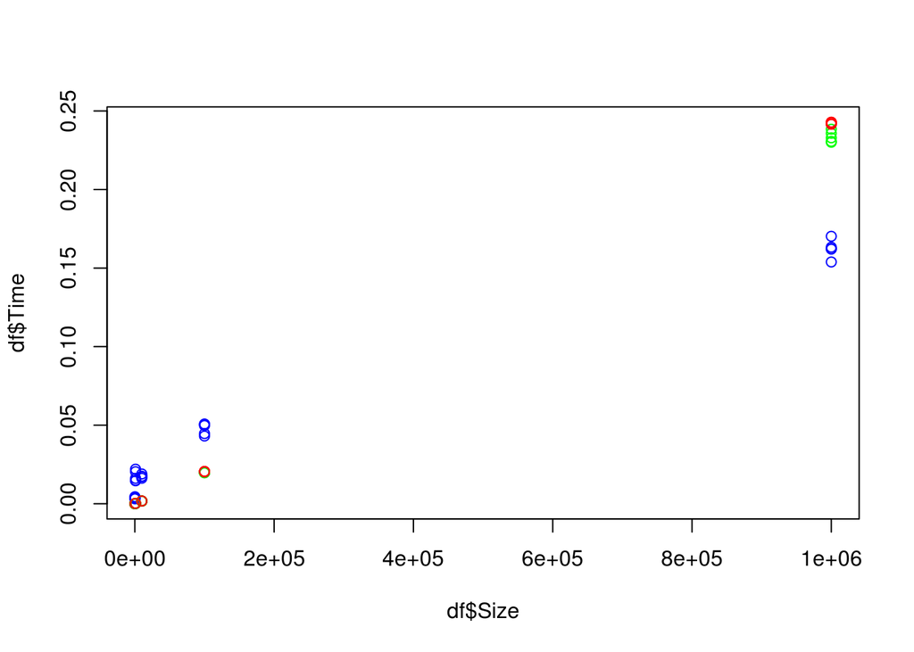

```r
  plot(df$Size,df$Time,col=c("red","blue","green")[df$Type])
```

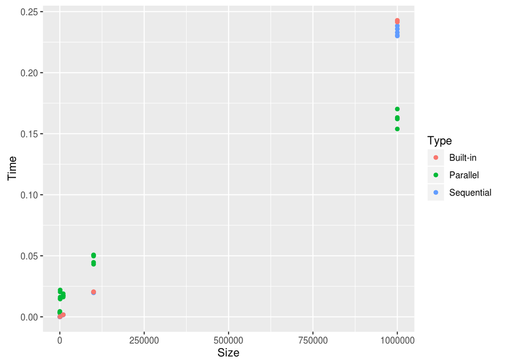

```r
  ggplot(data=df, aes(x=Size, y=Time, color=Type))+geom_point()
```

```r
  df_sum = ddply(df, c("Size", "Type"), summarize, num=length(Time), mean=mean(Time), sd= sd(Time), se=2*sd/sqrt(num))
  df_sum
```

```
##       Size        Type num      mean           sd           se
## 1      100    Built-in   5 0.0000126 1.140175e-06 1.019804e-06
## 2      100    Parallel   5 0.0037454 5.188842e-04 4.641041e-04
## 3      100  Sequential   5 0.0000098 4.472136e-07 4.000000e-07
## 4     1000    Built-in   5 0.0002078 3.834058e-06 3.429286e-06
## 5     1000    Parallel   5 0.0176116 3.378959e-03 3.022233e-03
## 6     1000  Sequential   5 0.0001278 1.095445e-06 9.797959e-07
## 7    10000    Built-in   5 0.0017194 1.165333e-05 1.042305e-05
## 8    10000    Parallel   5 0.0174410 9.699515e-04 8.675510e-04
## 9    10000  Sequential   5 0.0016958 4.669261e-05 4.176314e-05
## 10  100000    Built-in   5 0.0204072 1.263555e-04 1.130158e-04
## 11  100000    Parallel   5 0.0477688 3.609278e-03 3.228237e-03
## 12  100000  Sequential   5 0.0198892 1.405763e-04 1.257353e-04
## 13 1000000    Built-in   5 0.2422674 6.296517e-04 5.631776e-04
## 14 1000000    Parallel   5 0.1623540 5.800859e-03 5.188446e-03
## 15 1000000  Sequential   5 0.2335652 3.502431e-03 3.132669e-03
```

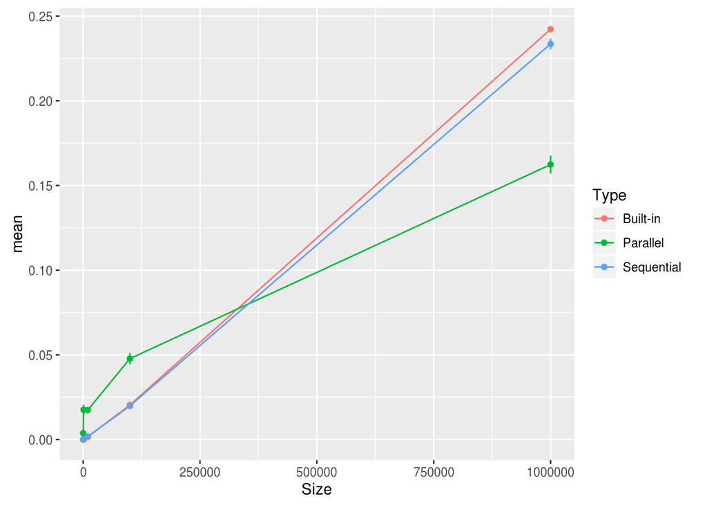

```r
 ggplot(data=df_sum,aes(x=Size, y=mean, ymin=mean-se, ymax= mean+se, color=Type))+geom_errorbar()+geom_point()+geom_line()
```

```r
 #ggplot(data=df, aes(x=Size, y=Time, color=factor(Type), shape=factor(option_compil)))+geom_point()
```

# The sizes

Instead of increasing the size of the array gradually, let’s try to choose different sizes in a pretty mixed way. In the following line, we have the array sizes we use in the script:

1000 2500000 10000 100 5000 1000000 800 100000 430 5000000 4000

```r
  library(ggplot2)
  library(plyr)

 df1 <- read.csv("/home/yacine/Documents/performance/M2R-ParallelQuicksort/data/yacine-S550CA_2016-01-31/measurements_15:37.csv",header=T)
  head(df1)
```

```
##   Size        Type     Time
## 1 1000  Sequential 0.000383
## 2 1000    Parallel 0.140358
## 3 1000    Built-in 0.000257
## 4 1000  Sequential 0.000164
## 5 1000    Parallel 0.108913
## 6 1000    Built-in 0.000257
```

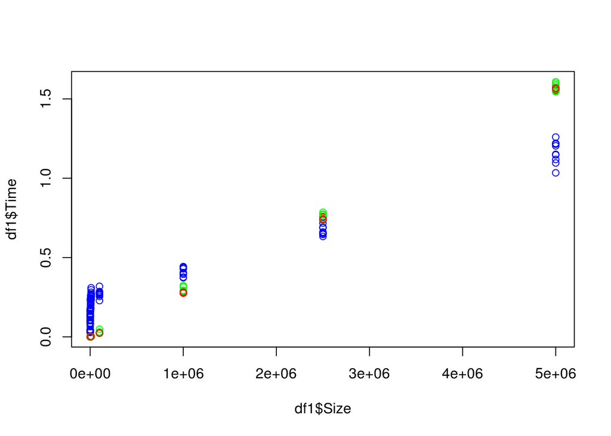

```r
  plot(df1$Size,df1$Time,col=c("red","blue","green")[df1$Type])
```

Let’s see the different execution times with ggplot

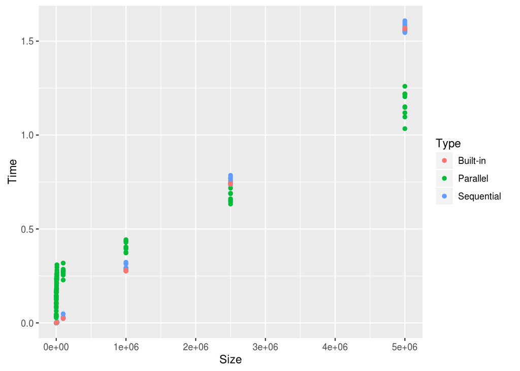

```r
 ggplot(data=df1, aes(x=Size, y=Time, color=Type))+geom_point()
```

## Confidence interval

Now let’s see the confidence interval

```r
    df1_sum = ddply(df1, c("Size", "Type"), summarize, num=length(Time), mean=mean(Time), sd= sd(Time), se=2*sd/sqrt(num))
  df1_sum
```

```
##       Size        Type num      mean           sd           se
## 1      100    Built-in  10 0.0000158 4.216370e-07 2.666667e-07
## 2      100    Parallel  10 0.0375457 5.667356e-03 3.584351e-03
## 3      100  Sequential  10 0.0000132 1.135292e-06 7.180220e-07
## 4      430    Built-in  10 0.0001748 1.619328e-06 1.024153e-06
## 5      430    Parallel  10 0.0965844 1.728921e-02 1.093466e-02
## 6      430  Sequential  10 0.0000677 5.478240e-06 3.464743e-06
## 7      800    Built-in  10 0.0002386 5.521674e-06 3.492214e-06
## 8      800    Parallel  10 0.1490409 1.709129e-02 1.080948e-02
## 9      800  Sequential  10 0.0001589 8.798163e-05 5.564447e-05
## 10    1000    Built-in  10 0.0002564 4.427189e-06 2.800000e-06
## 11    1000    Parallel  10 0.1489734 3.476853e-02 2.198955e-02
## 12    1000  Sequential  10 0.0001853 6.948389e-05 4.394547e-05
## 13    4000    Built-in  10 0.0008529 1.508826e-05 9.542653e-06
## 14    4000    Parallel  10 0.1867944 1.381444e-02 8.737016e-03
```

[output cut: 19 more lines]

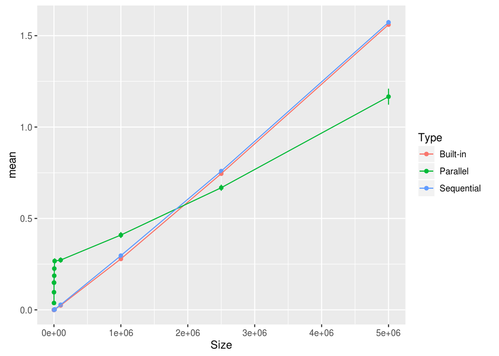

```r
 ggplot(data=df1_sum,aes(x=Size, y=mean, ymin=mean-se, ymax= mean+se, color=Type))+geom_errorbar()+geom_point()+geom_line()
```

Here we can see after applying the confidence interval that there is the very slight difference between the built in and the sequential algorithms for a little array size but when the size is increasing, the built in algorithm is a little bit better. For the parallel quick sort,like we said before, it is only efficient starting a certain array size and then we can notice the exact opposite of time evolution compared to the other 2 algorithms.

# The GCC compiler options

```r
 df2 <- read.csv("/home/yacine/Documents/performance/M2R-ParallelQuicksort/data/yacine-S550CA_2016-02-01/measurements_11:40.csv",header=T)
  head(df2)
```

```
##   Size Compilation        Type     Time
## 1 1000         -O1  Sequential 0.000290
## 2 1000         -O1    Parallel 0.172405
## 3 1000         -O1    Built-in 0.000251
## 4 1000         -O2  Sequential 0.000082
## 5 1000         -O2    Parallel 0.108279
## 6 1000         -O2    Built-in 0.000247
```

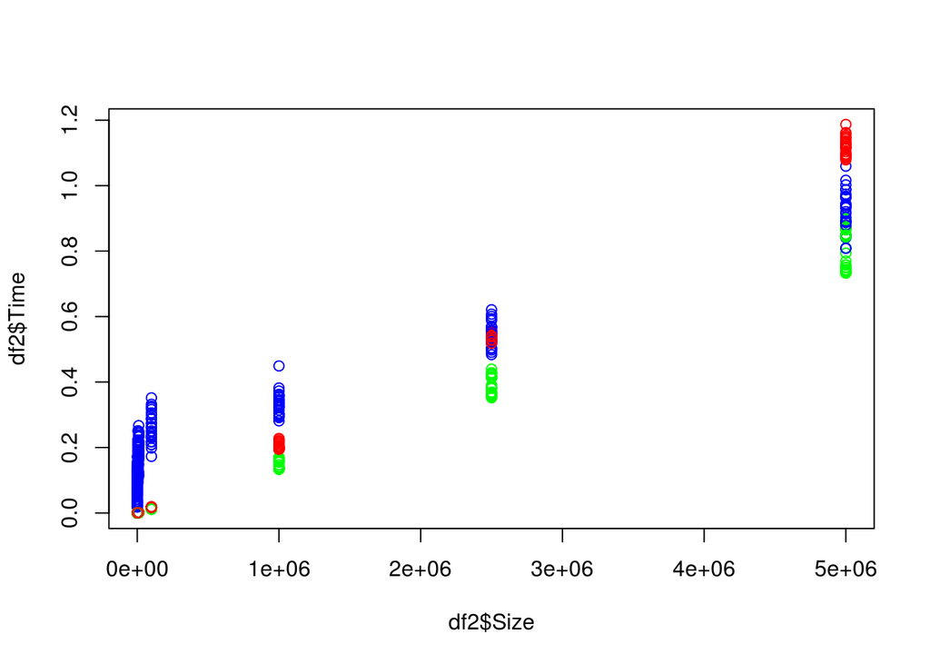

```r
  plot(df2$Size,df2$Time,col=c("red","blue","green")[df2$Type])
```

Let’s see the different execution times with ggplot

```r
   library(dplyr)
```

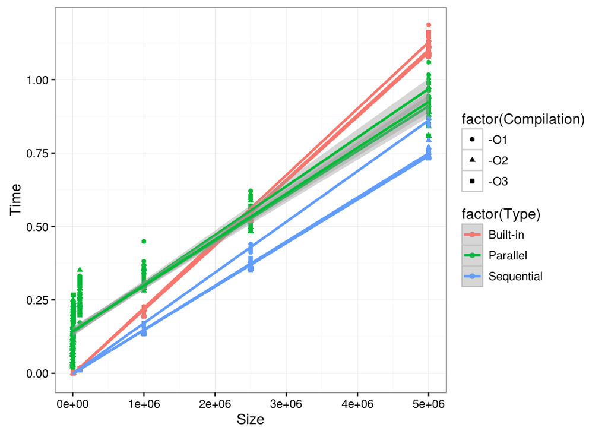

```r
ggplot(data=df2, aes(x=Size, y=Time, color=factor(Type), shape= factor(Compilation)))+geom_point()+theme_bw()+geom_smooth(method="lm")
```

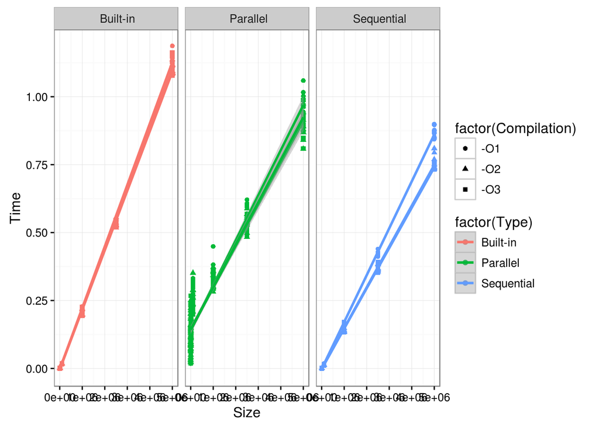

```r
ggplot(data=df2, aes(x=Size, y=Time, color=factor(Type), shape= factor(Compilation)))+geom_point()+theme_bw()+geom_smooth(method="lm")+facet_wrap(~ Type)
```